# Praat practical 1

Measuring your own voice

Dr Massimiliano Canzi

# Your recordings

`Did you know:` young male zebra finches learn their song from adult males, in a sensitive period between about 35 and 90 days after hatching.

*Source: Tchernichovski, Mitra, Lints & Nottebohm (2001), Science*

## Two practical sessions

Today you measure vowels, f0 and articulation rate in your own recordings. In the next session, the recordings of the whole class become the material for a mock speaker comparison, speaker profiling and a disguise test.

Both sessions build on the activities in chapters 2 and 4 of Leemann et al. (2024), with your voices in place of the book’s files.

## What you recorded

| File | Content | Used for |
| --- | --- | --- |
| `S07_words.wav` | 19 words in *Say ___ again*, three times | vowels today; profiling next time |
| `S07_A.wav` | sentences A | f0 and articulation rate today; known samples next time |
| `S07_B.wav` | sentences B | f0 and articulation rate today; questioned samples next time |
| `S07_A_disguise.wav` | sentences A, disguised | the disguise test next time |

Open copies of your files, and keep the originals untouched, as in real casework (session 6).

## Today

1. Praat basics
2. Vowels: annotating and measuring formants
3. f0 and articulation rate
4. The class data

# Praat basics

`Did you know:` a young zebra finch kept alone with its father imitates his song closely. When it can hear the model song more often, the imitation is less complete.

*Source: Tchernichovski, Lints, Mitra & Nottebohm (1999), PNAS*

## Opening a recording

1. Open Praat, then Open > Read from file…, and choose your `words` file
2. With the sound selected in the Objects window, click View & Edit
3. The top panel shows the waveform, the lower panel the spectrogram
4. Select a stretch with the mouse and press Tab to play it. Use the zoom buttons at the bottom to zoom in and out

## Settings for your voice

Praat’s default settings suit some voices better than others. Check two of them before you measure:

- Formants > Formant settings: set the maximum formant (called “formant ceiling” in recent versions) to about 5000 Hz for a low voice and 5500 Hz for a high voice
- Pitch > Pitch settings: set the pitch range to about 75–300 Hz for a low voice and 100–500 Hz for a high voice

If a formant track or pitch track looks wrong later, these settings are the first thing to change.

# Vowels

`Did you know:` zebra finch song imitation is not always gradual. In some young birds, a note stayed far from the model for days and was then corrected abruptly, by a sudden doubling of its period.

*Source: Tchernichovski, Mitra, Lints & Nottebohm (2001), Science*

## A TextGrid

1. In the Objects window, select your `words` recording, then Annotate > To TextGrid…
2. Type `vowel` as the tier name, leave the point tiers empty, and click OK
3. Select the Sound and the TextGrid together and click View & Edit
4. Click at the start of each vowel and press Enter to add a boundary, then do the same at its end. Type the word in the interval, for example `heed`
5. Save the TextGrid: select it in the Objects window, then Save > Save as text file…

## Where does the vowel start and end?

Mark the vowels of the eleven words from *heed* to *hud*. Between /h/ and /d/, the vowel is the stretch with clear formants and a regular waveform.

- At the start, the breathy noise of /h/ gives way to voicing. At the end, the formants stop where the closure for /d/ begins
- Start with the first reading of the list, then add the second and third

## Measuring formants

1. Formants > Show formants
2. Check that the red dots follow the dark formant bands. If they jump or miss a band, change the maximum formant in Formant settings
3. Click in the middle of the vowel and press F1, then F2 (on some laptops, Fn + F1). Praat shows the values in Hz
4. Write down F1 and F2 for each vowel in each of the three readings

The midpoint is the usual compromise: far enough from both consonants to be fairly stable. Session 4 showed that formant dynamics can also tell speakers apart.

## Three readings of the same word

- Compare your three measurements of the same vowel. How far apart are they, in Hz?
- Which vowels vary most in your own speech?

This is within-speaker variation. In a speaker comparison, a difference between two recordings only counts if it is larger than the speaker’s own variation (session 4).

# f0 and articulation rate

`Did you know:` in zebra finch song, a motif lasts only about half a second to one and a half seconds. A song bout repeats it several times.

*Source: Tchernichovski, Lints, Mitra & Nottebohm (1999), PNAS*

## f0 of the sentences

1. Open your recording of sentences A and click View & Edit
2. Pitch > Show pitch, then Pulses > Show pulses
3. Select all three sentences, then Pulses > Voice report
4. Write down the median, mean, standard deviation, minimum and maximum pitch

Look at the pitch track before you trust the numbers. Octave jumps, where the track suddenly halves or doubles, distort the mean and the range (session 2).

## Articulation rate

Articulation rate is the number of syllables per second, with pauses removed (session 2). Sentences A have 41 syllables in their careful form, sentences B have 42.

1. Select from the start of the first word to the end of the last, and note the duration shown in the bar below the spectrogram
2. Find the pauses longer than 100 ms, including those between sentences, and subtract their total duration
3. Divide the number of syllables by the remaining duration

## A and B

- Measure median f0 and articulation rate in sentences B in the same way
- Compare them with your values for sentences A: same speaker, same booth, same day, different sentences. Which measure changed more?

In the next session, sentences B are the questioned samples and sentences A the known ones, so this difference is exactly what a comparison has to allow for.

# The class data

## Entering your values

Enter your measurements in the class spreadsheet, under your ID:

- F1 and F2 of each vowel, in each of the three readings
- median f0, mean f0, standard deviation, minimum and maximum, and the articulation rate, for sentences A and B

We then look at the class data together in R.

## A vowel space for the class

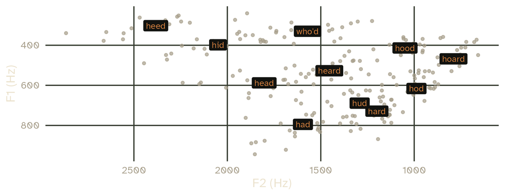

Simulated preview. Each grey point is one speaker’s vowel; in class, the points will be yours.

## What to look for

- How much do speakers differ for the same vowel? Part of the spread comes from vocal tract size: longer vocal tracts have lower formants overall
- Do speakers with different first languages use the same vowel space?
- Where do your own vowels fall?

These differences matter in the next session: a feature that varies a lot across the class says less about who is speaking than one that is rare.

## Sentences A and B across the class

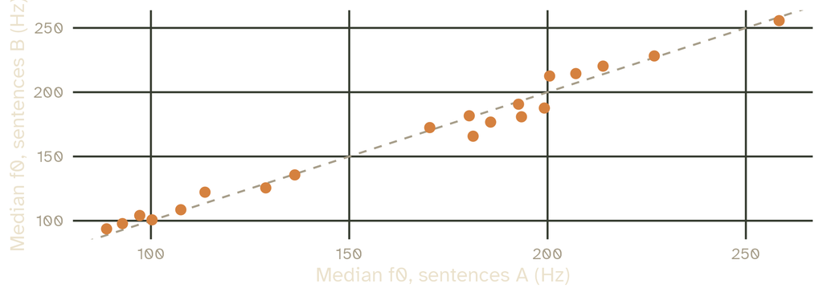

Simulated preview. Points on the dashed line have the same median f0 in both sets. The spread around the line is within-speaker variation; the spread along it is the difference between speakers.

## Summary

- A TextGrid marks where each vowel starts and ends, and makes measurements reproducible
- Formant and pitch settings must suit the voice, and every track needs checking by eye
- Median f0 and articulation rate describe a speaker’s pitch and speed
- Your own values vary between readings and sentences, and the class data show how much speakers differ from each other

## References

- Boersma, P., & Weenink, D. (2025). *Praat: Doing phonetics by computer* [Computer program]. https://www.praat.org
- Leemann, A., Perkins, R., Sullivan Buker, G., & Foulkes, P. (2024). *An Introduction to Forensic Phonetics and Forensic Linguistics*. Routledge. Activities 2A–2C and 4A.

## Sources of the animal facts

- Tchernichovski, O., Lints, T., Mitra, P. P., & Nottebohm, F. (1999). Vocal imitation in zebra finches is inversely related to model abundance. *PNAS*, 96(22), 12901–12904. https://doi.org/10.1073/pnas.96.22.12901
- Tchernichovski, O., Mitra, P. P., Lints, T., & Nottebohm, F. (2001). Dynamics of the vocal imitation process: How a zebra finch learns its song. *Science*, 291(5513), 2564–2569. https://doi.org/10.1126/science.1058522

## Slides and code

[figure not shown]

These slides

mcanzi.github.io/ws27_fss/09_praat_measuring.html

Code and all sessions

github.com/mcanzi/ws27_fss